# Homework 2

Ruipeng Wei

Case Western Reserve University  
rxw402@case.edu

2019-02-26

# library package

```r
set.seed(471)
library(MASS)
library(stats)
library(ggplot2)
library(class)
library(caret)
library(ROCR)
library(boot)
library(glmnet)
library(pls)
library(leaps)
library(rpart)
library(tree)
library(splines)
```

# Char4 - ex.13

## check dataset

```r
sum(!complete.cases(Boston))
```

```
## [1] 0
```

It tell us the data set does not missing any data.

```r
pander::pander(summary(Boston))
```

Table continues below

| crim | zn | indus | chas |
| --- | --- | --- | --- |
| Min. : 0.00632 | Min. : 0.00 | Min. : 0.46 | Min. :0.00000 |
| 1st Qu.: 0.08204 | 1st Qu.: 0.00 | 1st Qu.: 5.19 | 1st Qu.:0.00000 |
| Median : 0.25651 | Median : 0.00 | Median : 9.69 | Median :0.00000 |
| Mean : 3.61352 | Mean : 11.36 | Mean :11.14 | Mean :0.06917 |
| 3rd Qu.: 3.67708 | 3rd Qu.: 12.50 | 3rd Qu.:18.10 | 3rd Qu.:0.00000 |
| Max. :88.97620 | Max. :100.00 | Max. :27.74 | Max. :1.00000 |

Table continues below

| nox | rm | age | dis |
| --- | --- | --- | --- |
| Min. :0.3850 | Min. :3.561 | Min. : 2.90 | Min. : 1.130 |
| 1st Qu.:0.4490 | 1st Qu.:5.886 | 1st Qu.: 45.02 | 1st Qu.: 2.100 |
| Median :0.5380 | Median :6.208 | Median : 77.50 | Median : 3.207 |
| Mean :0.5547 | Mean :6.285 | Mean : 68.57 | Mean : 3.795 |
| 3rd Qu.:0.6240 | 3rd Qu.:6.623 | 3rd Qu.: 94.08 | 3rd Qu.: 5.188 |
| Max. :0.8710 | Max. :8.780 | Max. :100.00 | Max. :12.127 |

Table continues below

| rad | tax | ptratio | black |
| --- | --- | --- | --- |
| Min. : 1.000 | Min. :187.0 | Min. :12.60 | Min. : 0.32 |
| 1st Qu.: 4.000 | 1st Qu.:279.0 | 1st Qu.:17.40 | 1st Qu.:375.38 |
| Median : 5.000 | Median :330.0 | Median :19.05 | Median :391.44 |
| Mean : 9.549 | Mean :408.2 | Mean :18.46 | Mean :356.67 |
| 3rd Qu.:24.000 | 3rd Qu.:666.0 | 3rd Qu.:20.20 | 3rd Qu.:396.23 |
| Max. :24.000 | Max. :711.0 | Max. :22.00 | Max. :396.90 |

| lstat | medv |
| --- | --- |
| Min. : 1.73 | Min. : 5.00 |
| 1st Qu.: 6.95 | 1st Qu.:17.02 |
| Median :11.36 | Median :21.20 |
| Mean :12.65 | Mean :22.53 |
| 3rd Qu.:16.95 | 3rd Qu.:25.00 |
| Max. :37.97 | Max. :50.00 |

## generate the outcome

```r
m <- median(Boston$crim)
Boston$crim_cat <- Boston$crim
Boston[which(Boston$crim_cat>m),]$crim_cat <- "above"
Boston[which(Boston$crim_cat!="above"),]$crim_cat <- "below"
Boston <- Boston[ , -which(names(Boston) %in% c("chas","dis","nox"))]
```

Considering the the degree of freedom, I remove the `chas` which means Charles River dummy variable (1 if tract bounds river; 0 otherwise), `nox` which means nitric oxides concentration (parts per 10 million) and `dis` which means weighted distances to five Boston employment centers. There are the three variables that I thin it is not relative with the outcome.

## codebook

`crim` - per capital crime rate by town `zn` - proportion of residential land zoned for lots over 25,000 sq.ft. `indus` - proportion of non-retail business acres per town. `rm` - average number of rooms per dwelling `age` - proportion of owner-occupied units built prior to 1940 `dis` - weighted distances to five Boston employment centers `rad` - index of accessibility to radial highways `tax` - full-value property-tax rate per $10,000 `ptratio` - pupil-teacher ratio by town `black` - 1000(Bk - 0.63)^2 where Bk is the proportion of blacks by town `lstat` - % lower status of the population `medv` - Median value of owner-occupied homes in $1000’s `crim_cat` - the per capital crime rate by town is above median or below median

## exploratory of the data

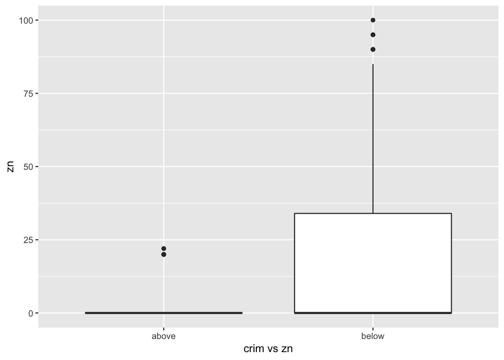

```r
ggplot(Boston,aes(x= crim_cat, y = zn))+
  geom_boxplot()+
        labs(x = "crim vs zn")
```

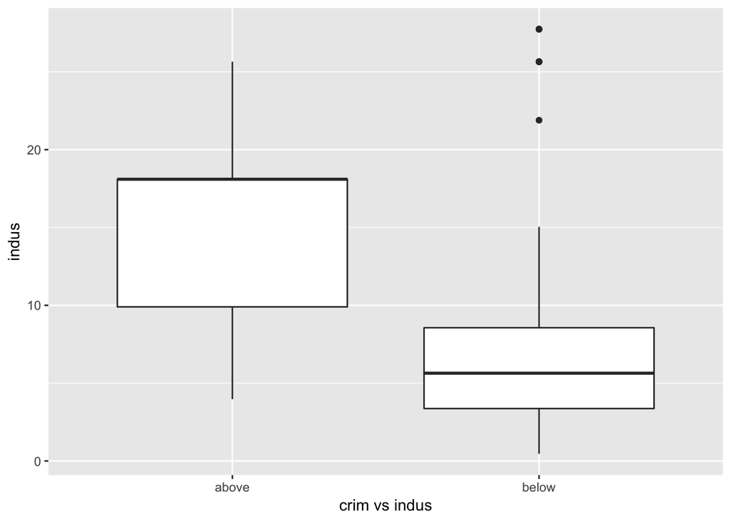

```r
ggplot(Boston,aes(x= crim_cat, y = indus))+
  geom_boxplot()+
        labs(x = "crim vs indus")
```

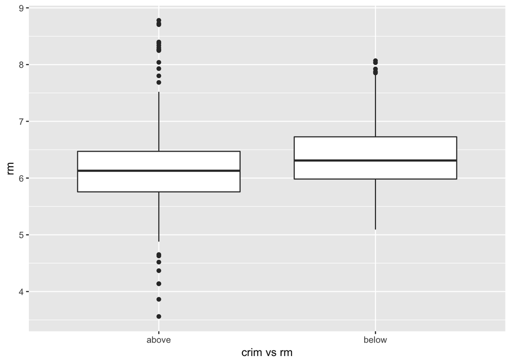

```r
ggplot(Boston,aes(x= crim_cat, y = rm))+
  geom_boxplot()+
        labs(x = "crim vs rm")
```

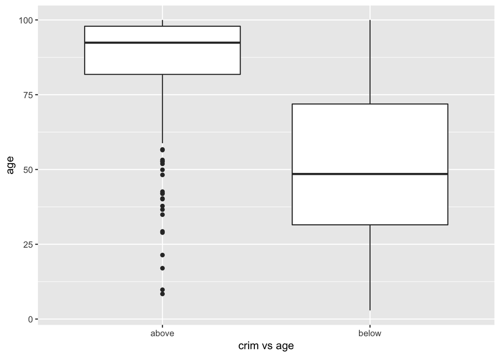

```r
ggplot(Boston,aes(x= crim_cat, y = age))+
  geom_boxplot()+
        labs(x = "crim vs age")
```

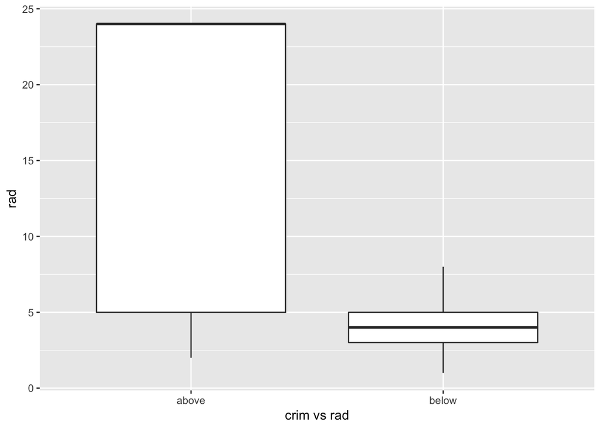

```r
ggplot(Boston,aes(x= crim_cat, y = rad))+
  geom_boxplot()+
        labs(x = "crim vs rad")
```

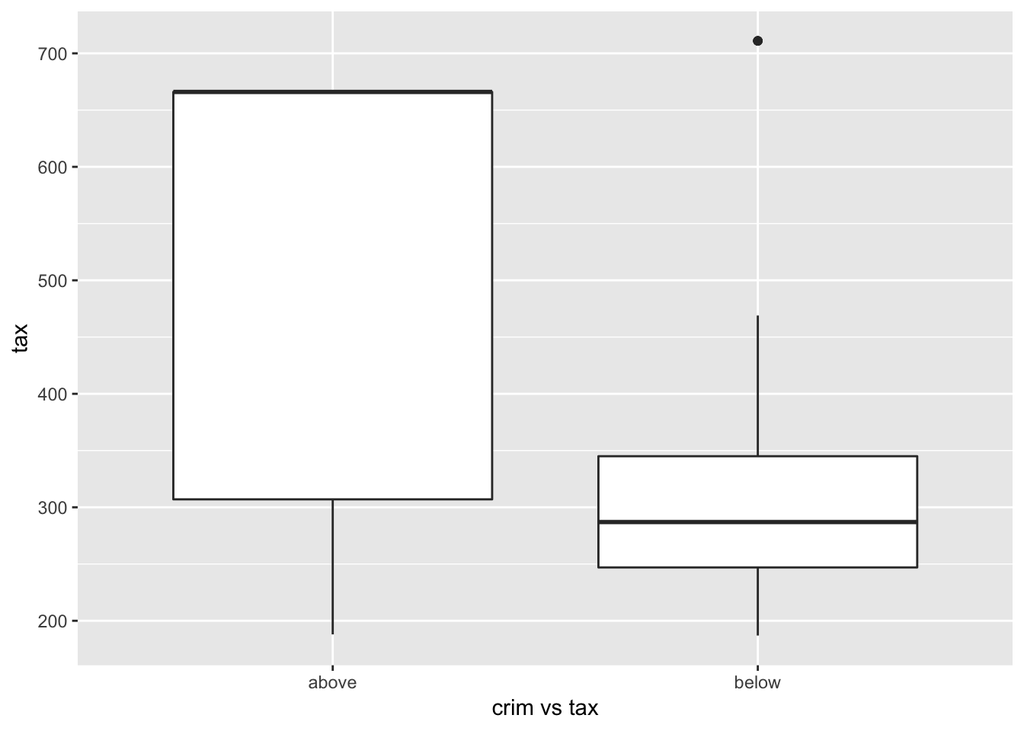

```r
ggplot(Boston,aes(x= crim_cat, y = tax))+
  geom_boxplot()+
        labs(x = "crim vs tax")
```

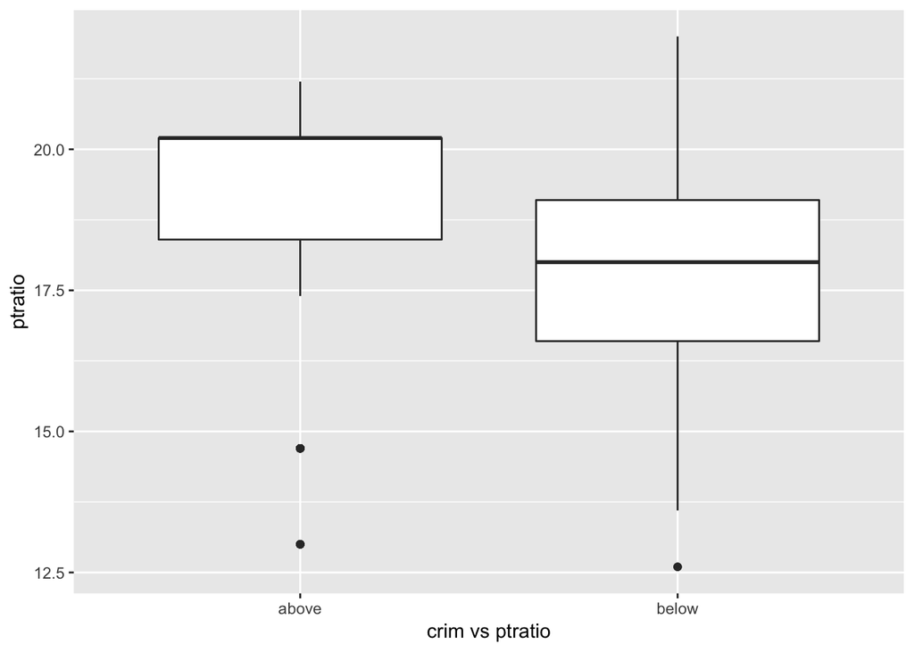

```r
ggplot(Boston,aes(x= crim_cat, y = ptratio))+
  geom_boxplot()+
        labs(x = "crim vs ptratio")
```

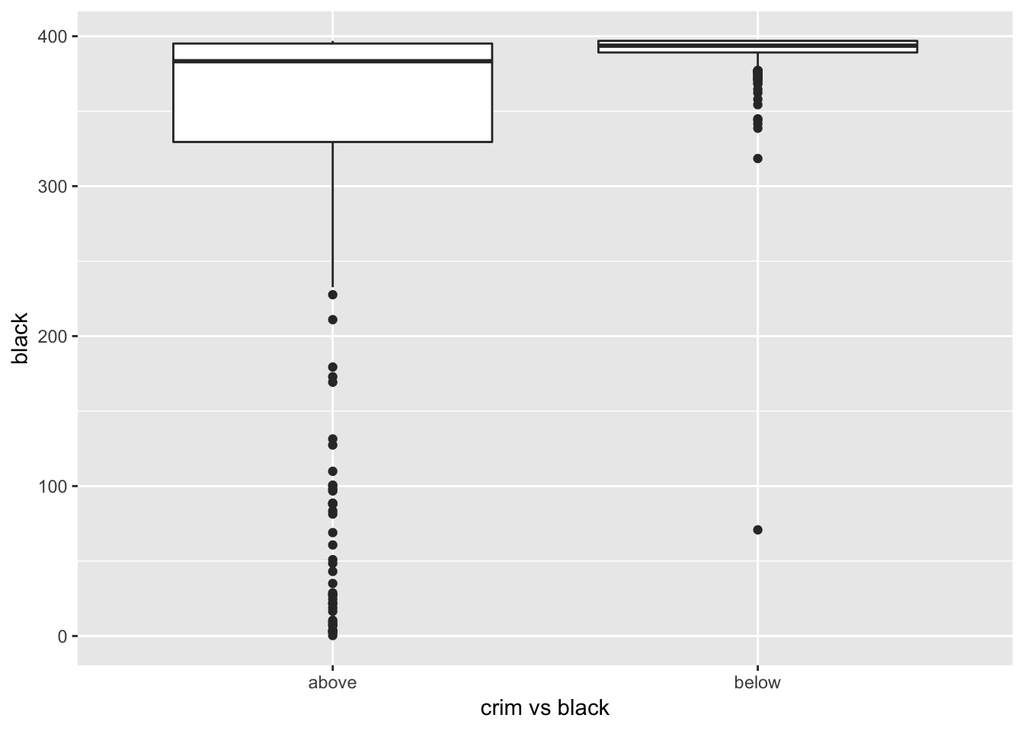

```r
ggplot(Boston,aes(x= crim_cat, y = black))+
  geom_boxplot()+
        labs(x = "crim vs black")
```

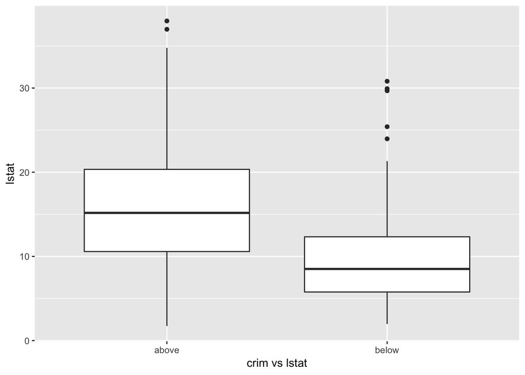

```r
ggplot(Boston,aes(x= crim_cat, y = lstat))+
  geom_boxplot()+
        labs(x = "crim vs lstat")
```

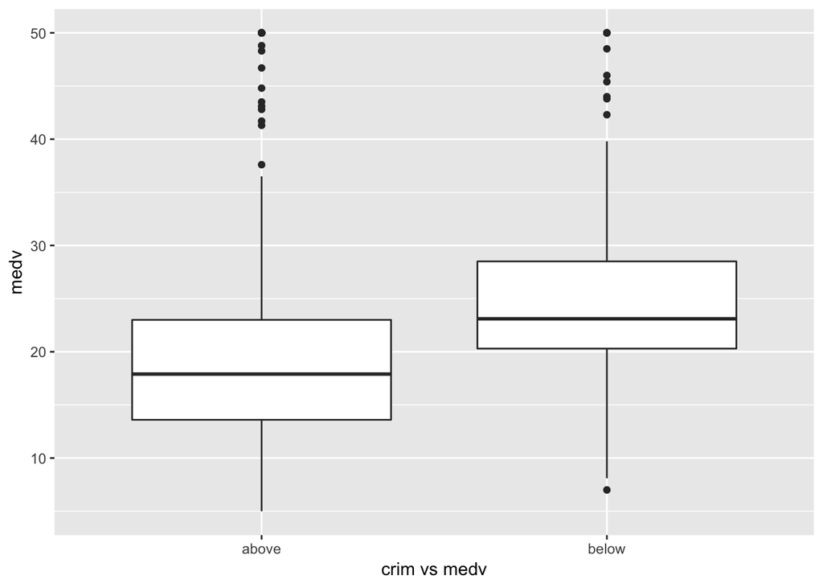

```r
ggplot(Boston,aes(x= crim_cat, y = medv))+
  geom_boxplot()+
        labs(x = "crim vs medv")
```

## seperate data into training set and testing set

```r
train_ind <- sample(seq_len(nrow(Boston)), size = floor(0.8 * nrow(Boston)))
train <- Boston[train_ind, ]
test <- Boston[-train_ind, ]
```

## logistic regression model

### build logistic regression model in training dataset

```r
gfit <- glm(as.factor(crim_cat) ~ zn + indus + rm + age +
            rad + tax + ptratio + black + lstat + medv, data = train,
            family="binomial"(link="logit"))

gfit$rule.5 <- ifelse(gfit$fitted.values >= 0.5,"Predict Above", "Predict Blove")
table(gfit$rule.5,gfit$y)
```

```
##
##                   0   1
##   Predict Above  38 187
##   Predict Blove 160  19
```

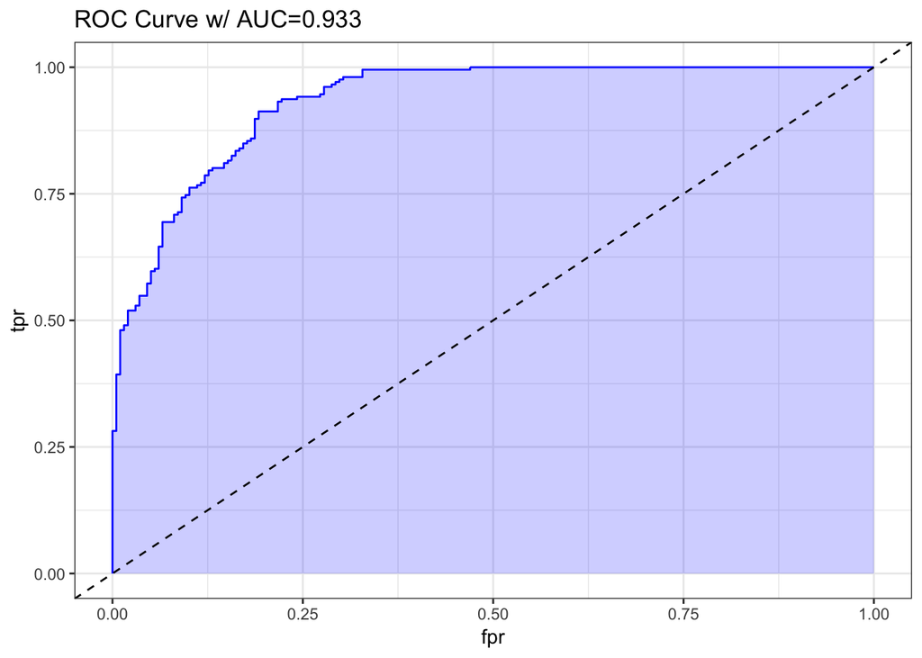

```r
prob <- predict(gfit, train, type="response")
pred <- prediction(prob, train$crim_cat)
perf <- performance(pred, measure = "tpr", x.measure = "fpr")
auc <- performance(pred, measure="auc")
auc <- round(auc@y.values[[1]],3)
roc.data <- data.frame(fpr=unlist(perf@x.values),
tpr=unlist(perf@y.values),
model="GLM")
ggplot(roc.data, aes(x=fpr, ymin=0, ymax=tpr)) +
geom_ribbon(alpha=0.2, fill = "blue") +
geom_line(aes(y=tpr), col = "blue") +
geom_abline(intercept = 0, slope = 1, lty = "dashed") +
labs(title = paste0("ROC Curve w/ AUC=", auc)) +
theme_bw()
```

The area of the ROC curve is above 90%, looks pretty high. Based on the table, the recall is about 91%, specificity is about 81%, precision is about 83%, the accuracy is about 86%.

### apply the model in test data.

```r
predict1 <- predict(gfit, newdata = test)
predict1 <- as.numeric(predict1)
predict1 <- exp(predict1)/(1+exp(predict1))
predict1 <- as.data.frame(predict1)
predict1 <- cbind.data.frame(predict1,test$crim_cat)
colnames(predict1) <- c("predict","real")
predict1[which(predict1$predict<0.5),]$predict <- "Above"
predict1[which(predict1$predict!="Above"),]$predict <- "Below"
table(predict1$predict,predict1$real)
```

```
##
##         above below
##   Above    46     2
##   Below     9    45
```

The accuracy is about 89%.Recall is 84%, specificity is 96% and precision is about 96%.

## LDA

### build the LDA model

```r
lda1 = lda(as.factor(crim_cat) ~ zn + indus + rm + age +
            rad + tax + ptratio + black + lstat + medv, data = train)

table(train$crim_cat, predict(lda1)$class)
```

```
##
##         above below
##   above   156    42
##   below    16   190
```

The accuracy is about 86%, recall is about 91%, the specificity is about 82%, the precision is about 80%.

### apply LDA model in test dataset

```r
predict2 <- predict(lda1, newdata = test)
table(test$crim_cat,predict2$class)
```

```
##
##         above below
##   above    43    12
##   below     3    44
```

The accuracy is about 86%, recall is about 93%, specificity is about 79%, and the precision is about 78%.

## KNN

### build KNN model on train data

```r
knn.pred=knn(as.matrix(train[,2:11]), as.matrix(test[,2:11]), cl=as.factor(train$crim_cat), k=2,prob = T)
table(test$crim_cat, knn.pred)
```

```
##        knn.pred
##         above below
##   above    52     3
##   below     4    43
```

The accuracy of knn model is about 93%, the recall is about 93%, the specificity is about 93%, the precision is about 95%.

## Conclusion

Based on the accuracy of the three methods, KNN has the highest accuracy, then is the logistic regression, the worst one is LDA. From this result, I can assume that the decision boundary is very non-linear based on the chosen data set and predictor. Because logistic regression has a linear decision boundary, while LDA has a even more restrict boundary. Thus, these two model has a worse performance than KNN.

# Char5 - ex.9

## (a)

```r
mean_medv <- mean(Boston$medv)
mean_medv
```

```
## [1] 22.53281
```

Based on the data set, we can gain a mean value of medv is about 22.5 which could be considered as the estimate value of population mean value.

## (b)

```r
sd_medv1 <- sqrt(sum((Boston$medv-mean_medv)^2)/length(Boston$medv-1))
sd_medv1
```

```
## [1] 9.188012
```

```r
sd(Boston$medv)
```

```
## [1] 9.197104
```

We also could use the standard deviation of medv, 9.19, in the Boston data set to estimate the population standard deviation.

## (c)

```r
sd_medv2 <- boot(Boston$medv,sd,R=100)
sd_medv2
```

```
##
## ORDINARY NONPARAMETRIC BOOTSTRAP
##
##
## Call:
## boot(data = Boston$medv, statistic = sd, R = 100)
##
##
## Bootstrap Statistics :
##     original  bias    std. error
## t1* 9.197104       0           0
```

By using bootstrap and repeat it 100 times, the standard deviation of the population is estimated about 9.20.

## (d)

```r
mean_medv + sd_medv2$t0 #upper limit
```

```
## [1] 31.72991
```

```r
mean_medv - sd_medv2$t0 #lower limit
```

```
## [1] 13.3357
```

## (e)

```r
median_medv <- boot(Boston$medv,median,R=100)
median_medv
```

```
##
## ORDINARY NONPARAMETRIC BOOTSTRAP
##
##
## Call:
## boot(data = Boston$medv, statistic = median, R = 100)
##
##
## Bootstrap Statistics :
##     original  bias    std. error
## t1*     21.2       0           0
```

Thus the estimate median of the medv in population is about 21.2.

## (f)

```r
stdmedian = function(x, index){
  sqrt(sum((x-median(x))^2)/length(x-1))
}
stdmedian(Boston$medv)
```

```
## [1] 9.284176
```

```r
standmedian_medv <- boot(Boston$medv, stdmedian, R=100)
standmedian_medv
```

```
##
## ORDINARY NONPARAMETRIC BOOTSTRAP
##
##
## Call:
## boot(data = Boston$medv, statistic = stdmedian, R = 100)
##
##
## Bootstrap Statistics :
##     original  bias    std. error
## t1* 9.284176       0           0
```

Based on this result, the estimate median standard deviation is about 9.28 which is close but a little larger than the estimate standard deviation. Thus I can state that the data is clustered more at mean than at median.

## (g)

```r
per = function(x,index){
  quantile(x,probs = 0.1)
}
boot(Boston$medv, per,R = 100)
```

```
##
## ORDINARY NONPARAMETRIC BOOTSTRAP
##
##
## Call:
## boot(data = Boston$medv, statistic = per, R = 100)
##
##
## Bootstrap Statistics :
##     original  bias    std. error
## t1*    12.75       0           0
```

Based on the result of bootstrap, the estimate of 10th percentile is about 12.75.

```r
stdper = function(x, index){
  sqrt(sum((x-quantile(x,probs = 0.1))^2)/length(x-1))
}
stdper(Boston$medv)
```

```
## [1] 13.42099
```

```r
boot(Boston$medv, stdper, R=100)
```

```
##
## ORDINARY NONPARAMETRIC BOOTSTRAP
##
##
## Call:
## boot(data = Boston$medv, statistic = stdper, R = 100)
##
##
## Bootstrap Statistics :
##     original  bias    std. error
## t1* 13.42099       0           0
```

The estimate of 10th percentile standard deviation, 13.42 is larger than the estimate of 10th percentile, 12.75. But it is not so much large which means the data is clustered.

# Chr6 - ex.9

## loading data

```r
College <- read.csv("College.csv")
sum(!complete.cases(College))
```

```
## [1] 0
```

## (a)

```r
train_ind <- sample(seq_len(nrow(College)), size = floor(0.8 * nrow(College)))
train <- College[train_ind, ]
test <- College[-train_ind, ]
```

## (b)

```r
ex9_lm <- lm(Apps ~ ., train[,-1])
pre_ex9_lm <- predict.lm(ex9_lm,newdata = test[,-1])
mean((pre_ex9_lm - test$Apps)^2)
```

```
## [1] 1242775
```

## (c)

```r
x <- model.matrix(Apps ~ ., train[,-1])[,-1]
y <- train$Apps
ex9_glmnet <- cv.glmnet(x, y, alpha=0)
pre_ex9_glmnet <- predict (ex9_glmnet, s = ex9_glmnet$lambda, newx = model.matrix(Apps ~ ., test[,-1])[,-1])
mean((pre_ex9_glmnet - test$Apps)^2)
```

```
## [1] 6616728
```

## (d)

```r
ex9_lasso <- cv.glmnet(x, y, alpha=1)
pre_ex9_lasso <- predict (ex9_lasso, s = ex9_lasso$lambda, newx = model.matrix(Apps ~ ., test[,-1])[,-1])
mean((pre_ex9_lasso - test$Apps)^2)
```

```
## [1] 2356416
```

## (e)

```r
ex9_pcr=pcr(Apps ~ ., data=train[,-1] ,scale=TRUE, validation ="CV")
pre_ex9_pcr=predict (ex9_pcr ,test, ncomp =ex9_pcr$ncomp)
mean((pre_ex9_pcr-test$Apps)^2)
```

```
## [1] 1242775
```

## (f)

```r
ex9_plsr <- plsr(Apps ~ ., data=train[,-1] ,scale=TRUE, validation ="CV")
pre_ex9_plsr=predict (ex9_plsr ,test, ncomp =ex9_plsr$ncomp)
mean((pre_ex9_plsr-test$Apps)^2)
```

```
## [1] 1242775
```

## (g)

# Chr6 - ex.11

```r
train_ind <- sample(seq_len(nrow(Boston)), size = floor(0.8 * nrow(Boston)))
train <- Boston[train_ind, ]
test <- Boston[-train_ind, ]
```

## (a)

### best subset

```r
ex11_bestsubset <- regsubsets (crim ~., train)
summary(ex11_bestsubset)
```

```
## Subset selection object
## Call: regsubsets.formula(crim ~ ., train)
## 11 Variables  (and intercept)
##               Forced in Forced out
## zn                FALSE      FALSE
## indus             FALSE      FALSE
## rm                FALSE      FALSE
## age               FALSE      FALSE
## rad               FALSE      FALSE
## tax               FALSE      FALSE
## ptratio           FALSE      FALSE
## black             FALSE      FALSE
## lstat             FALSE      FALSE
## medv              FALSE      FALSE
## crim_catbelow     FALSE      FALSE
## 1 subsets of each size up to 8
## Selection Algorithm: exhaustive
##          zn  indus rm  age rad tax ptratio black lstat medv crim_catbelow
## 1  ( 1 ) " " " "   " " " " "*" " " " "     " "   " "   " "  " "
## 2  ( 1 ) " " " "   " " " " "*" " " " "     " "   "*"   " "  " "
## 3  ( 1 ) " " " "   " " " " "*" " " " "     "*"   "*"   " "  " "
## 4  ( 1 ) " " " "   " " " " "*" " " " "     "*"   "*"   "*"  " "
## 5  ( 1 ) " " "*"   " " " " "*" " " " "     "*"   "*"   "*"  " "
## 6  ( 1 ) " " "*"   "*" " " "*" " " " "     "*"   "*"   "*"  " "
## 7  ( 1 ) "*" " "   "*" " " "*" "*" " "     "*"   "*"   "*"  " "
## 8  ( 1 ) "*" " "   "*" " " "*" "*" "*"     "*"   "*"   "*"  " "
```

```r
predict.regsubsets = function(object, newdata, id, ...) {
    form = as.formula(object$call[[2]])
    mat = model.matrix(form, newdata)
    coefi = coef(object, id = id)
    mat[, names(coefi)] %*% coefi
}

pre_ex11_bestsubset <- predict.regsubsets(ex11_bestsubset,test, id = 1)
mean((pre_ex11_bestsubset-test$crim)^2)
```

```
## [1] 40.36158
```

### lasso

```r
x <- model.matrix(crim ~ ., train)[,-1]
y <- train$crim
ex11_lasso <- cv.glmnet(x, y, alpha=1)
pre_ex11_lasso <- predict (ex11_lasso, s = ex11_lasso$lambda, newx = model.matrix(crim ~ ., test)[,-1])
mean((pre_ex11_lasso - test$crim)^2)
```

```
## [1] 41.33646
```

### ridge

```r
x <- model.matrix(crim ~ ., train)[,-1]
y <- train$crim
ex11_ridge <- cv.glmnet(x, y, alpha=0)
pre_ex11_ridge <- predict (ex11_ridge, s = ex11_ridge$lambda, newx = model.matrix(crim ~ ., test)[,-1])
mean((pre_ex11_ridge - test$crim)^2)
```

```
## [1] 51.4846
```

### PCR

```r
ex11_pcr=pcr(crim ~ ., data=train ,scale=TRUE, validation ="CV")
pre_ex11_pcr=predict (ex11_pcr ,test, ncomp =ex11_pcr$ncomp)
ex11_pcr$ncomp
```

```
## [1] 11
```

```r
mean((pre_ex11_pcr-test$crim)^2)
```

```
## [1] 39.77193
```

### conclusion

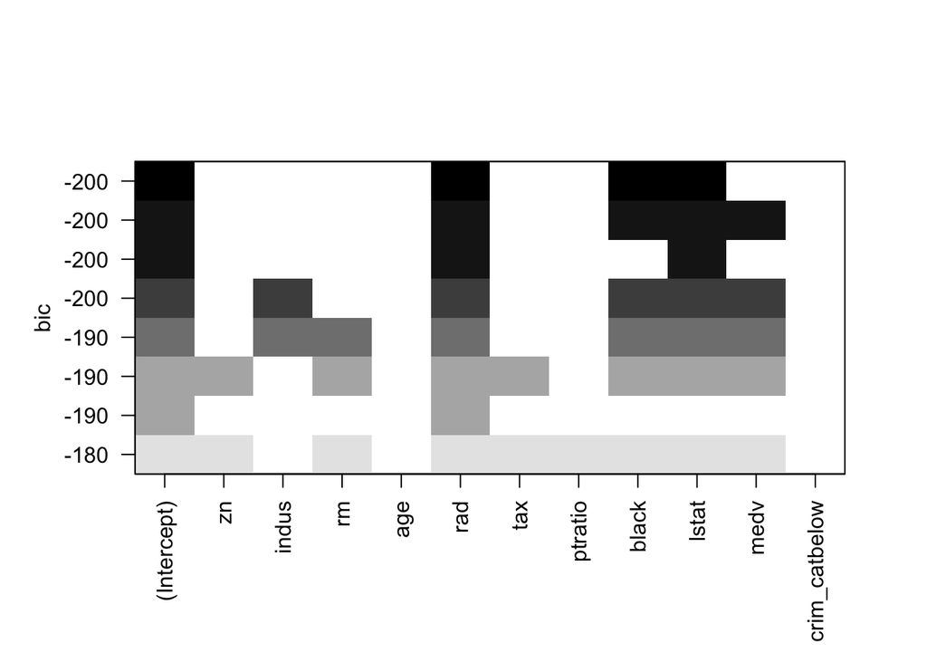

```r
plot(regsubsets (crim ~., train))
```

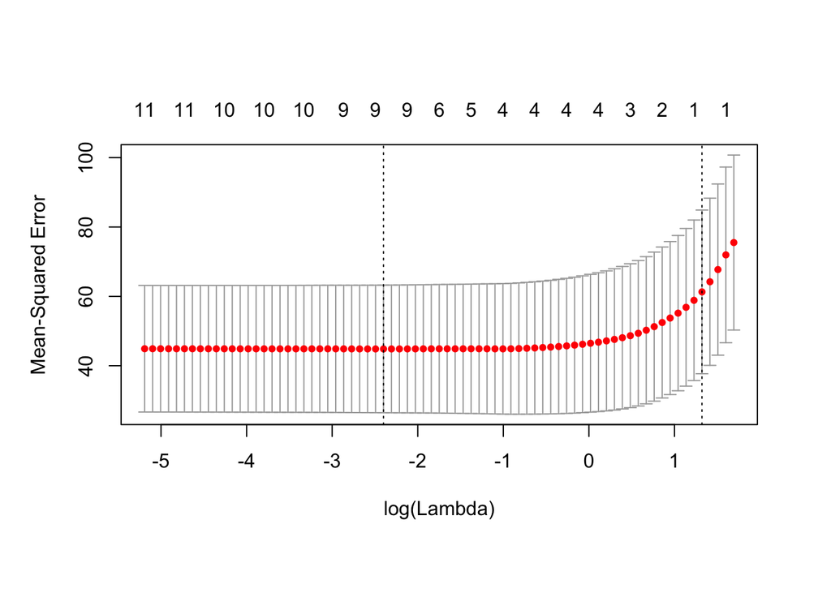

```r
plot(ex11_lasso)
```

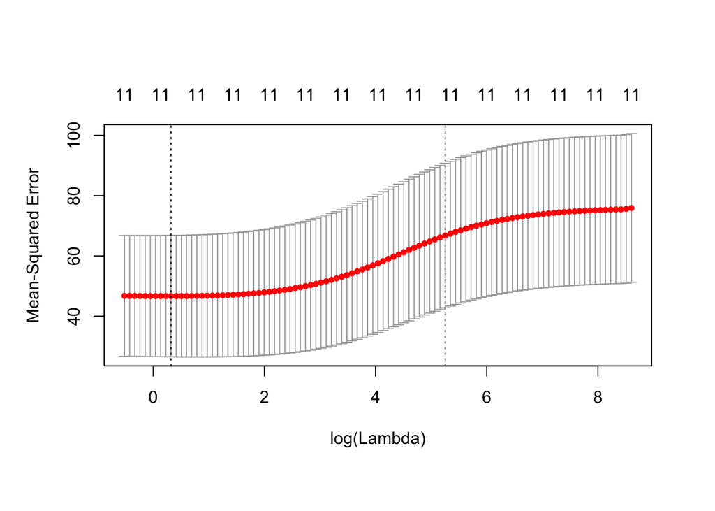

```r
plot(ex11_ridge)
```

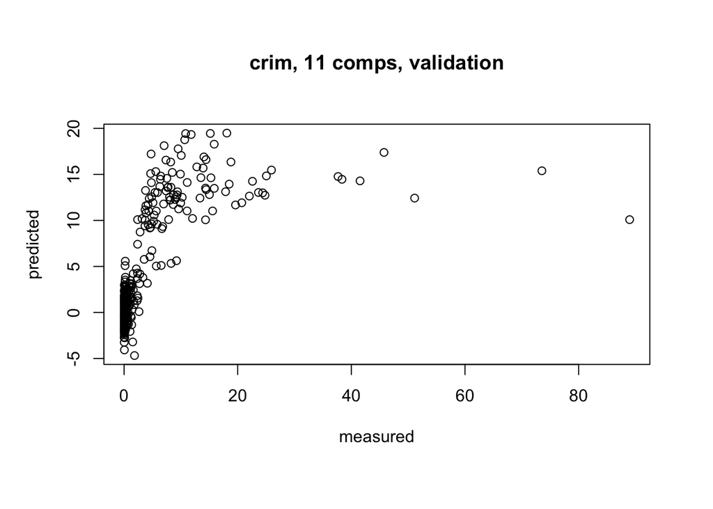

```r
plot(ex11_pcr)
```

## (b)

```r
nrow(train)/13
```

```
## [1] 31.07692
```

## (c)

I choose all the predictors in the data set. First, it will not cause any serious problem to the model. Second, I choose the pcr method which means it will re-coordinate the predictors, so I already give up the interpretation of the model. Thus, the number of the predictors will not be so important.

# Chr7 - ex9

## (a)

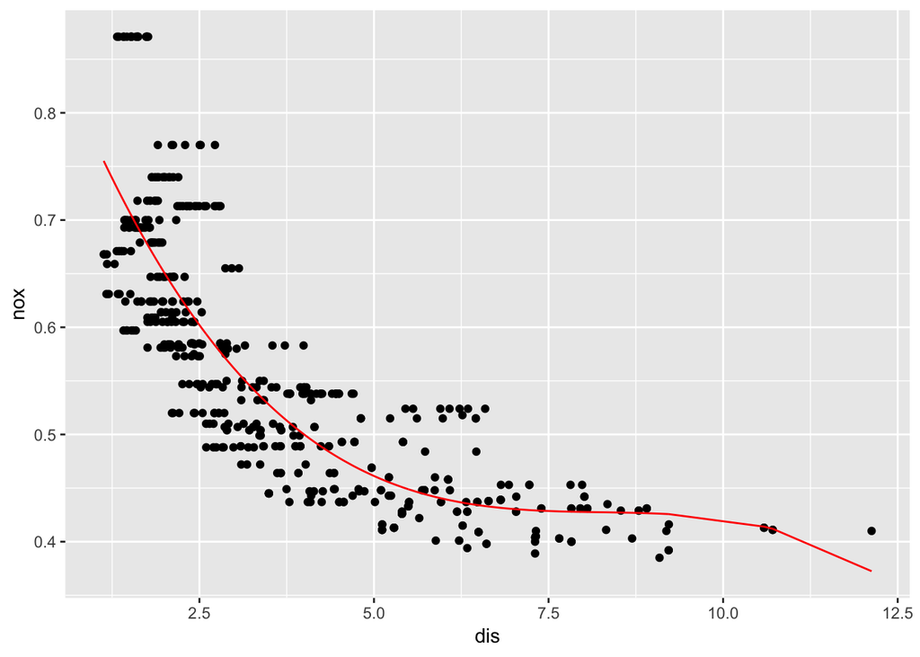

```r
Boston <- MASS::Boston
ex9_cubic <- lm(nox ~ poly(dis,3),data=Boston)
ggplot(data = Boston, aes(x = dis, y =nox)) +
  geom_point() +
  geom_line(aes(x=Boston$dis, predict(ex9_cubic, Boston)),col="red")
```

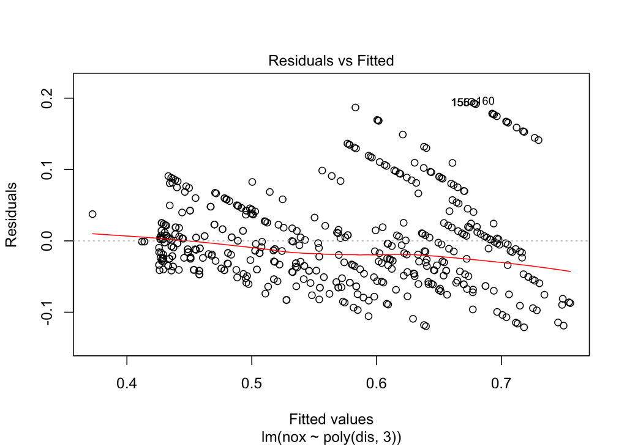

```r
plot(ex9_cubic,1)
```

```r
mean(abs(ex9_cubic$residuals))
```

```
## [1] 0.04630861
```

```r
summary(ex9_cubic)
```

```
##
## Call:
## lm(formula = nox ~ poly(dis, 3), data = Boston)
##
## Residuals:
##       Min        1Q    Median        3Q       Max
## -0.121130 -0.040619 -0.009738  0.023385  0.194904
##
## Coefficients:
##                Estimate Std. Error t value Pr(>|t|)
## (Intercept)    0.554695   0.002759 201.021  < 2e-16 ***
## poly(dis, 3)1 -2.003096   0.062071 -32.271  < 2e-16 ***
## poly(dis, 3)2  0.856330   0.062071  13.796  < 2e-16 ***
## poly(dis, 3)3 -0.318049   0.062071  -5.124 4.27e-07 ***
## ---
## Signif. codes:  0 '***' 0.001 '**' 0.01 '*' 0.05 '.' 0.1 ' ' 1
##
## Residual standard error: 0.06207 on 502 degrees of freedom
## Multiple R-squared:  0.7148, Adjusted R-squared:  0.7131
## F-statistic: 419.3 on 3 and 502 DF,  p-value: < 2.2e-16
```

The average absolute residuals is about 0.046, residual standard error is about 0.062.

## (b)

```r
par(mfrow=c(2,5),mar=c(1,1,1,1))
for(i in 1:10){
  ex9_cubic <- lm(nox ~ poly(dis,i), data = Boston)
  ggplot(data = Boston, aes(x = dis, y =nox)) +
  geom_point() +
  geom_line(aes(x=Boston$dis, predict(ex9_cubic, Boston)),col="red") +
  ggtitle(paste("d =", i))
}
```

```r
ex9_poly <- list()
sum_risidual <- vector()
for(i in 1:10){
  ex9_poly[[i]] <- lm(nox ~ poly(dis,i), data = Boston)
  sum_risidual[i] <- sum((ex9_poly[[i]]$residuals)^2)
}
sum_risidual
```

```
##  [1] 2.768563 2.035262 1.934107 1.932981 1.915290 1.878257 1.849484
##  [8] 1.835630 1.833331 1.832171
```

The sum of residual’s square associated from 1 to 10 is above.

## (c)

```r
anova(ex9_poly[[1]],ex9_poly[[2]],ex9_poly[[3]],ex9_poly[[4]],ex9_poly[[5]],ex9_poly[[6]],ex9_poly[[7]],ex9_poly[[8]],ex9_poly[[9]],ex9_poly[[10]])
```

|  | Res.Df | RSS | Df | Sum of Sq | F | Pr(>F) |
| --- | --- | --- | --- | --- | --- | --- |
| 1 | 504 | 2.768563 | NA | NA | NA | NA |
| 2 | 503 | 2.035262 | 1 | 0.733300990 | 198.1168600 | 4.359043e-38 |
| 3 | 502 | 1.934107 | 1 | 0.101155162 | 27.3292186 | 2.535399e-07 |
| 4 | 501 | 1.932981 | 1 | 0.001125380 | 0.3040453 | 5.816062e-01 |
| 5 | 500 | 1.915290 | 1 | 0.017691366 | 4.7796989 | 2.926475e-02 |
| 6 | 499 | 1.878257 | 1 | 0.037032663 | 10.0051615 | 1.656919e-03 |
| 7 | 498 | 1.849484 | 1 | 0.028773684 | 7.7738227 | 5.504872e-03 |
| 8 | 497 | 1.835630 | 1 | 0.013853926 | 3.7429327 | 5.360073e-02 |
| 9 | 496 | 1.833331 | 1 | 0.002298885 | 0.6210926 | 4.310188e-01 |
| 10 | 495 | 1.832171 | 1 | 0.001159681 | 0.3133124 | 5.759079e-01 |

```r
summary(ex9_poly[[3]])
```

```
##
## Call:
## lm(formula = nox ~ poly(dis, i), data = Boston)
##
## Residuals:
##       Min        1Q    Median        3Q       Max
## -0.121130 -0.040619 -0.009738  0.023385  0.194904
##
## Coefficients:
##                Estimate Std. Error t value Pr(>|t|)
## (Intercept)    0.554695   0.002759 201.021  < 2e-16 ***
## poly(dis, i)1 -2.003096   0.062071 -32.271  < 2e-16 ***
## poly(dis, i)2  0.856330   0.062071  13.796  < 2e-16 ***
## poly(dis, i)3 -0.318049   0.062071  -5.124 4.27e-07 ***
## ---
## Signif. codes:  0 '***' 0.001 '**' 0.01 '*' 0.05 '.' 0.1 ' ' 1
##
## Residual standard error: 0.06207 on 502 degrees of freedom
## Multiple R-squared:  0.7148, Adjusted R-squared:  0.7131
## F-statistic: 419.3 on 3 and 502 DF,  p-value: < 2.2e-16
```

```r
summary(ex9_poly[[4]])
```

```
##
## Call:
## lm(formula = nox ~ poly(dis, i), data = Boston)
##
## Residuals:
##      Min       1Q   Median       3Q      Max
## -0.12295 -0.04089 -0.01073  0.02290  0.19471
##
## Coefficients:
##                Estimate Std. Error t value Pr(>|t|)
## (Intercept)    0.554695   0.002761  200.88  < 2e-16 ***
## poly(dis, i)1 -2.003096   0.062115  -32.25  < 2e-16 ***
## poly(dis, i)2  0.856330   0.062115   13.79  < 2e-16 ***
## poly(dis, i)3 -0.318049   0.062115   -5.12 4.36e-07 ***
## poly(dis, i)4  0.033547   0.062115    0.54    0.589
## ---
## Signif. codes:  0 '***' 0.001 '**' 0.01 '*' 0.05 '.' 0.1 ' ' 1
##
## Residual standard error: 0.06211 on 501 degrees of freedom
## Multiple R-squared:  0.7149, Adjusted R-squared:  0.7127
## F-statistic: 314.1 on 4 and 501 DF,  p-value: < 2.2e-16
```

According to the anova result, it seems that the third method which is the cubic model is sufficient to explain the variance and the fourth model is unnecessary. So I think the degree of three is the optimal one.

## (d)

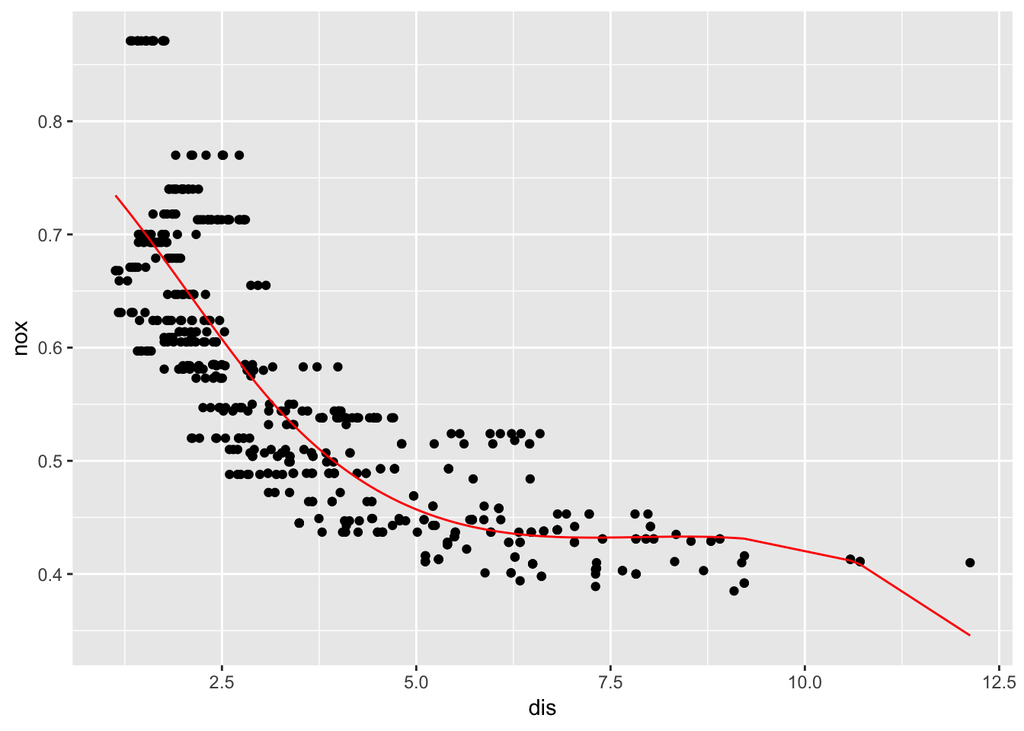

```r
ex9_bs <- lm(Boston$nox ~ bs(Boston$dis, df = 4))
pred_ex9_bs <- predict(ex9_bs,newdata=data.frame(Boston$dis),se=T)
ggplot(data = Boston, aes(x = dis, y =nox)) +
  geom_point() +
  geom_line(aes(x=Boston$dis, predict(ex9_bs, Boston)),col="red")
```

## (e)

```r
ex9_bs <- list()
sum_risidual <- vector()
par(mfrow=c(2,4),mar=c(1,1,1,1))
for(i in 3:10){
  ex9_bs[[i]] <- lm(Boston$nox ~ bs(Boston$dis, df = i))
  pred_ex9_bs[[i]] <- predict (ex9_bs[[i]],newdata=data.frame(Boston$dis),se=T)
  ggplot(data = Boston, aes(x = dis, y =nox)) +
  geom_point() +
  geom_line(aes(x=Boston$dis, predict(ex9_bs[[i]], Boston)),col="red")
  sum_risidual[i] <- sum((ex9_bs[[i]]$residuals)^2)
}
sum_risidual
```

```
##  [1]       NA       NA 1.934107 1.922775 1.840173 1.833966 1.829884
##  [8] 1.816995 1.825653 1.792535
```

## (f)

```r
anova(ex9_bs[[3]],ex9_bs[[4]],ex9_bs[[5]],ex9_bs[[6]],ex9_bs[[7]],ex9_bs[[8]],ex9_bs[[9]],ex9_bs[[10]])
```

|  | Res.Df | RSS | Df | Sum of Sq | F | Pr(>F) |
| --- | --- | --- | --- | --- | --- | --- |
| 1 | 502 | 1.934107 | NA | NA | NA | NA |
| 2 | 501 | 1.922775 | 1 | 0.011331714 | 3.129199 | 7.751726e-02 |
| 3 | 500 | 1.840173 | 1 | 0.082602191 | 22.810203 | 2.359159e-06 |
| 4 | 499 | 1.833966 | 1 | 0.006206898 | 1.714006 | 1.910739e-01 |
| 5 | 498 | 1.829884 | 1 | 0.004081457 | 1.127075 | 2.889178e-01 |
| 6 | 497 | 1.816995 | 1 | 0.012889389 | 3.559344 | 5.979616e-02 |
| 7 | 496 | 1.825653 | 1 | -0.008657454 | NA | NA |
| 8 | 495 | 1.792535 | 1 | 0.033117621 | 9.145274 | 2.623094e-03 |

```r
summary(ex9_bs[[5]])
```

```
##
## Call:
## lm(formula = Boston$nox ~ bs(Boston$dis, df = i))
##
## Residuals:
##       Min        1Q    Median        3Q       Max
## -0.132814 -0.039097 -0.008521  0.023493  0.197761
##
## Coefficients:
##                         Estimate Std. Error t value Pr(>|t|)
## (Intercept)              0.67248    0.01996  33.699  < 2e-16 ***
## bs(Boston$dis, df = i)1  0.08311    0.02875   2.891  0.00401 **
## bs(Boston$dis, df = i)2 -0.13460    0.01985  -6.782 3.35e-11 ***
## bs(Boston$dis, df = i)3 -0.25505    0.03477  -7.336 8.95e-13 ***
## bs(Boston$dis, df = i)4 -0.26785    0.04059  -6.599 1.06e-10 ***
## bs(Boston$dis, df = i)5 -0.26103    0.05214  -5.007 7.69e-07 ***
## ---
## Signif. codes:  0 '***' 0.001 '**' 0.01 '*' 0.05 '.' 0.1 ' ' 1
##
## Residual standard error: 0.06067 on 500 degrees of freedom
## Multiple R-squared:  0.7286, Adjusted R-squared:  0.7259
## F-statistic: 268.5 on 5 and 500 DF,  p-value: < 2.2e-16
```

```r
summary(ex9_bs[[6]])
```

```
##
## Call:
## lm(formula = Boston$nox ~ bs(Boston$dis, df = i))
##
## Residuals:
##       Min        1Q    Median        3Q       Max
## -0.128538 -0.037813 -0.009987  0.022644  0.195494
##
## Coefficients:
##                         Estimate Std. Error t value Pr(>|t|)
## (Intercept)              0.65622    0.02370  27.689  < 2e-16 ***
## bs(Boston$dis, df = i)1  0.10222    0.03516   2.907  0.00381 **
## bs(Boston$dis, df = i)2 -0.02963    0.02338  -1.267  0.20571
## bs(Boston$dis, df = i)3 -0.15959    0.02791  -5.718 1.86e-08 ***
## bs(Boston$dis, df = i)4 -0.22815    0.03324  -6.864 1.99e-11 ***
## bs(Boston$dis, df = i)5 -0.26272    0.04930  -5.329 1.50e-07 ***
## bs(Boston$dis, df = i)6 -0.24002    0.05434  -4.417 1.23e-05 ***
## ---
## Signif. codes:  0 '***' 0.001 '**' 0.01 '*' 0.05 '.' 0.1 ' ' 1
##
## Residual standard error: 0.06062 on 499 degrees of freedom
## Multiple R-squared:  0.7295, Adjusted R-squared:  0.7263
## F-statistic: 224.3 on 6 and 499 DF,  p-value: < 2.2e-16
```

Since it is another linear method, so I used anova again. According to the anova result, the third one which means the model with degree of 5 is sufficient to explain the variance of the outcome.

# Chr7 - ex9.

```r
OJ <- ISLR::OJ
sum(!complete.cases(OJ)) #no missing
```

```
## [1] 0
```

```r
str(OJ)
```

```
## 'data.frame':    1070 obs. of  18 variables:
##  $ Purchase      : Factor w/ 2 levels "CH","MM": 1 1 1 2 1 1 1 1 1 1 ...
##  $ WeekofPurchase: num  237 239 245 227 228 230 232 234 235 238 ...
##  $ StoreID       : num  1 1 1 1 7 7 7 7 7 7 ...
##  $ PriceCH       : num  1.75 1.75 1.86 1.69 1.69 1.69 1.69 1.75 1.75 1.75 ...
##  $ PriceMM       : num  1.99 1.99 2.09 1.69 1.69 1.99 1.99 1.99 1.99 1.99 ...
##  $ DiscCH        : num  0 0 0.17 0 0 0 0 0 0 0 ...
##  $ DiscMM        : num  0 0.3 0 0 0 0 0.4 0.4 0.4 0.4 ...
##  $ SpecialCH     : num  0 0 0 0 0 0 1 1 0 0 ...
##  $ SpecialMM     : num  0 1 0 0 0 1 1 0 0 0 ...
##  $ LoyalCH       : num  0.5 0.6 0.68 0.4 0.957 ...
##  $ SalePriceMM   : num  1.99 1.69 2.09 1.69 1.69 1.99 1.59 1.59 1.59 1.59 ...
##  $ SalePriceCH   : num  1.75 1.75 1.69 1.69 1.69 1.69 1.69 1.75 1.75 1.75 ...
##  $ PriceDiff     : num  0.24 -0.06 0.4 0 0 0.3 -0.1 -0.16 -0.16 -0.16 ...
##  $ Store7        : Factor w/ 2 levels "No","Yes": 1 1 1 1 2 2 2 2 2 2 ...
##  $ PctDiscMM     : num  0 0.151 0 0 0 ...
##  $ PctDiscCH     : num  0 0 0.0914 0 0 ...
##  $ ListPriceDiff : num  0.24 0.24 0.23 0 0 0.3 0.3 0.24 0.24 0.24 ...
##  $ STORE         : num  1 1 1 1 0 0 0 0 0 0 ...
```

```r
summary(OJ)
```

```
##  Purchase WeekofPurchase     StoreID        PriceCH         PriceMM
##  CH:653   Min.   :227.0   Min.   :1.00   Min.   :1.690   Min.   :1.690
##  MM:417   1st Qu.:240.0   1st Qu.:2.00   1st Qu.:1.790   1st Qu.:1.990
##           Median :257.0   Median :3.00   Median :1.860   Median :2.090
##           Mean   :254.4   Mean   :3.96   Mean   :1.867   Mean   :2.085
##           3rd Qu.:268.0   3rd Qu.:7.00   3rd Qu.:1.990   3rd Qu.:2.180
##           Max.   :278.0   Max.   :7.00   Max.   :2.090   Max.   :2.290
##      DiscCH            DiscMM         SpecialCH        SpecialMM
##  Min.   :0.00000   Min.   :0.0000   Min.   :0.0000   Min.   :0.0000
##  1st Qu.:0.00000   1st Qu.:0.0000   1st Qu.:0.0000   1st Qu.:0.0000
##  Median :0.00000   Median :0.0000   Median :0.0000   Median :0.0000
##  Mean   :0.05186   Mean   :0.1234   Mean   :0.1477   Mean   :0.1617
##  3rd Qu.:0.00000   3rd Qu.:0.2300   3rd Qu.:0.0000   3rd Qu.:0.0000
##  Max.   :0.50000   Max.   :0.8000   Max.   :1.0000   Max.   :1.0000
##     LoyalCH          SalePriceMM     SalePriceCH      PriceDiff
##  Min.   :0.000011   Min.   :1.190   Min.   :1.390   Min.   :-0.6700
##  1st Qu.:0.325257   1st Qu.:1.690   1st Qu.:1.750   1st Qu.: 0.0000
##  Median :0.600000   Median :2.090   Median :1.860   Median : 0.2300
##  Mean   :0.565782   Mean   :1.962   Mean   :1.816   Mean   : 0.1465
##  3rd Qu.:0.850873   3rd Qu.:2.130   3rd Qu.:1.890   3rd Qu.: 0.3200
##  Max.   :0.999947   Max.   :2.290   Max.   :2.090   Max.   : 0.6400
##  Store7      PctDiscMM        PctDiscCH       ListPriceDiff
##  No :714   Min.   :0.0000   Min.   :0.00000   Min.   :0.000
##  Yes:356   1st Qu.:0.0000   1st Qu.:0.00000   1st Qu.:0.140
##            Median :0.0000   Median :0.00000   Median :0.240
##            Mean   :0.0593   Mean   :0.02731   Mean   :0.218
##            3rd Qu.:0.1127   3rd Qu.:0.00000   3rd Qu.:0.300
##            Max.   :0.4020   Max.   :0.25269   Max.   :0.440
##      STORE
##  Min.   :0.000
##  1st Qu.:0.000
##  Median :2.000
##  Mean   :1.631
##  3rd Qu.:3.000
##  Max.   :4.000
```

## (a)

```r
levels(OJ$Purchase)
```

```
## [1] "CH" "MM"
```

```r
OJ$Purchase = factor(OJ$Purchase, levels(OJ$Purchase), ordered=T)
train <- OJ[sample(nrow(OJ),800),]
test <- setdiff(OJ, train)
```

## (b)

```r
tree1 <- rpart(Purchase ~ ., data = train, method= "class")
summary(tree1)
```

```
## Call:
## rpart(formula = Purchase ~ ., data = train, method = "class")
##   n= 800
##
##           CP nsplit rel error    xerror       xstd
## 1 0.48888889      0 1.0000000 1.0000000 0.04387030
## 2 0.02222222      1 0.5111111 0.5365079 0.03665241
## 3 0.01904762      3 0.4666667 0.5428571 0.03681017
## 4 0.01000000      6 0.4031746 0.5206349 0.03624891
##
## Variable importance
##        LoyalCH      PriceDiff  ListPriceDiff    SalePriceMM    SalePriceCH
##             62              9              7              4              3
##        PriceCH        StoreID      PctDiscCH        PriceMM WeekofPurchase
##              3              3              2              2              2
##         DiscCH          STORE
##              2              1
##
## Node number 1: 800 observations,    complexity param=0.4888889
##   predicted class=CH  expected loss=0.39375  P(node) =1
##     class counts:   485   315
##    probabilities: 0.606 0.394
##   left son=2 (496 obs) right son=3 (304 obs)
##   Primary splits:
##       LoyalCH   < 0.48285   to the right, improve=126.76670, (0 missing)
##       StoreID   < 3.5       to the right, improve= 32.41837, (0 missing)
##       PriceDiff < 0.31      to the right, improve= 21.02715, (0 missing)
##       Store7    splits as  RL, improve= 18.36846, (0 missing)
##       STORE     < 0.5       to the left,  improve= 18.36846, (0 missing)
##   Surrogate splits:
##       StoreID        < 3.5       to the right, agree=0.634, adj=0.036, (0 split)
##       WeekofPurchase < 227.5     to the right, agree=0.628, adj=0.020, (0 split)
##       SalePriceMM    < 1.285     to the right, agree=0.622, adj=0.007, (0 split)
##       PriceDiff      < -0.625    to the right, agree=0.622, adj=0.007, (0 split)
##       PctDiscMM      < 0.384491  to the left,  agree=0.622, adj=0.007, (0 split)
##
## Node number 2: 496 observations,    complexity param=0.01904762
##   predicted class=CH  expected loss=0.1733871  P(node) =0.62
##     class counts:   410    86
##    probabilities: 0.827 0.173
```

[output cut: 102 more lines]

```
##
## Node number 13: 96 observations
##   predicted class=MM  expected loss=0.28125  P(node) =0.12
##     class counts:    27    69
##    probabilities: 0.281 0.719
##
## Node number 22: 10 observations
##   predicted class=CH  expected loss=0.1  P(node) =0.0125
##     class counts:     9     1
##    probabilities: 0.900 0.100
##
## Node number 23: 66 observations
##   predicted class=MM  expected loss=0.3484848  P(node) =0.0825
##     class counts:    23    43
##    probabilities: 0.348 0.652
```

```r
pre_tree1 <- table(predict(tree1, type="class"), train$Purchase)
1-sum(diag(pre_tree1))/sum(pre_tree1)
```

```
## [1] 0.15875
```

The error rate of the tree is about 0.16. The terminal nodes are 7.

## (c)

```r
names(tree1)
```

```
##  [1] "frame"               "where"               "call"
##  [4] "terms"               "cptable"             "method"
##  [7] "parms"               "control"             "functions"
## [10] "numresp"             "splits"              "csplit"
## [13] "variable.importance" "y"                   "ordered"
```

```r
tree1
```

```
## n= 800
##
## node), split, n, loss, yval, (yprob)
##       * denotes terminal node
##
##  1) root 800 315 CH (0.60625000 0.39375000)
##    2) LoyalCH>=0.48285 496  86 CH (0.82661290 0.17338710)
##      4) LoyalCH>=0.705699 294  19 CH (0.93537415 0.06462585) *
##      5) LoyalCH< 0.705699 202  67 CH (0.66831683 0.33168317)
##       10) ListPriceDiff>=0.235 126  23 CH (0.81746032 0.18253968) *
##       11) ListPriceDiff< 0.235 76  32 MM (0.42105263 0.57894737)
##         22) PriceDiff>=0.215 10   1 CH (0.90000000 0.10000000) *
##         23) PriceDiff< 0.215 66  23 MM (0.34848485 0.65151515) *
##    3) LoyalCH< 0.48285 304  75 MM (0.24671053 0.75328947)
##      6) LoyalCH>=0.2761415 130  51 MM (0.39230769 0.60769231)
##       12) PriceDiff>=0.31 34  10 CH (0.70588235 0.29411765) *
##       13) PriceDiff< 0.31 96  27 MM (0.28125000 0.71875000) *
##      7) LoyalCH< 0.2761415 174  24 MM (0.13793103 0.86206897) *
```

## (d)

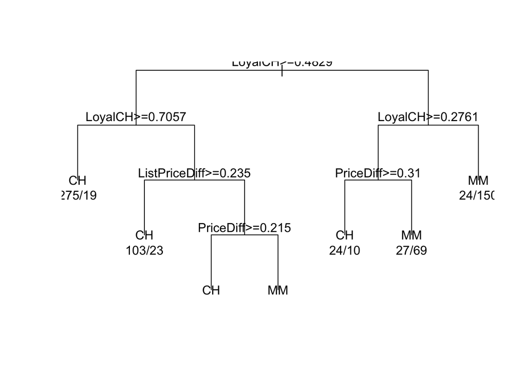

```r
plot(tree1, uniform=T); text(tree1, use.n=T)
```

## (e)

```r
pre <- predict(tree1, newdata = test, type="class")
table(test$Purchase, predict(tree1, newdata = test, type="class"))
```

```
##
##       CH  MM
##   CH 539 101
##   MM  73 333
```

## (f)

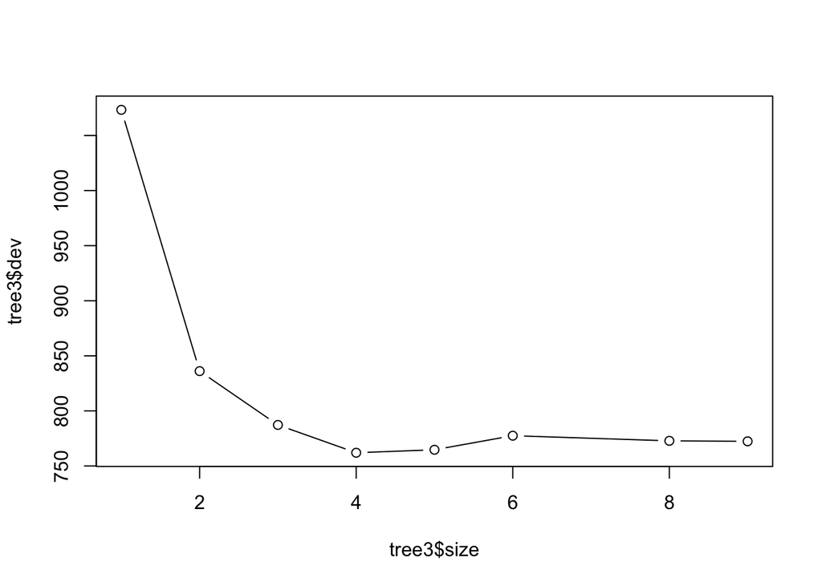

```r
tree2 <- tree(Purchase ~ ., data = train, method= "class")
tree3 <- cv.tree(tree2, K=10)
plot(tree3$size ,tree3$dev ,type="b")
```

```r
tree3$dev
```

```
## [1]  772.4040  772.8169  777.4929  764.7066  762.0194  787.2554  836.0999
## [8] 1073.3056
```

## (g)

```r
tree4 <- rpart(Purchase ~ ., data = train, method= "class", control = rpart.control(xval = 10))
printcp(tree4)
```

```
##
## Classification tree:
## rpart(formula = Purchase ~ ., data = train, method = "class",
##     control = rpart.control(xval = 10))
##
## Variables actually used in tree construction:
## [1] ListPriceDiff LoyalCH       PriceDiff
##
## Root node error: 315/800 = 0.39375
##
## n= 800
##
##         CP nsplit rel error  xerror     xstd
## 1 0.488889      0   1.00000 1.00000 0.043870
## 2 0.022222      1   0.51111 0.54286 0.036810
## 3 0.019048      3   0.46667 0.51429 0.036084
## 4 0.010000      6   0.40317 0.49206 0.035489
```

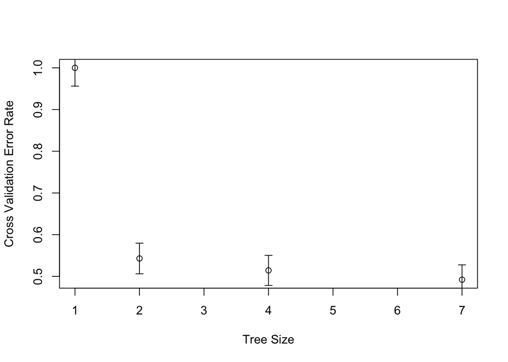

```r
x <- tree4$cptable[,2] + 1
y <- tree4$cptable[,4]
sd <- tree4$cptable[,5]
plot(y ~ x + 1, xlab="Tree Size", ylab="Cross Validation Error Rate")
arrows(x, y-sd, x, y+sd, length=0.05, angle=90, code=3)
```

## (h)

When tree size equal to 7, the tree model has the lowest error rate. But the error rate when tree size = 7 falls in 1 sd of the error rate when tree size = 4.

## (i)

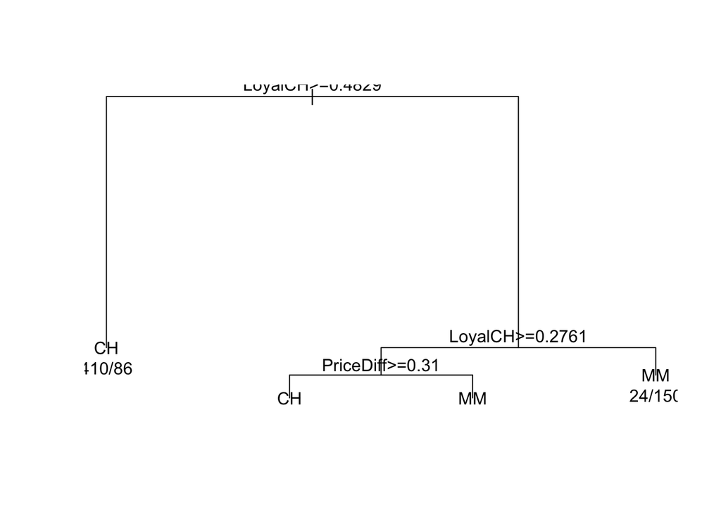

```r
tree5 <- rpart(Purchase ~ ., data = train, method= "class", control = rpart.control(cp = 0.02))
plot(tree5);text(tree5, use.n=T)
```

Cross-validation result leads to the pruned tree with tree size is 4.

## (j)

```r
pre_tree5 <- table(predict(tree4, type="class"), train$Purchase)

1-sum(diag(pre_tree1))/sum(pre_tree1)
```

```
## [1] 0.15875
```

```r
1-sum(diag(pre_tree5))/sum(pre_tree5)
```

```
## [1] 0.15875
```

## (k)

```r
unprune.pred <- table(predict(tree1, test, type="class"), test$Purchase)
1-sum(diag(unprune.pred))/sum(unprune.pred)
```

```
## [1] 0.166348
```

```r
prune.pred <- table(predict(tree5, test, type="class"), test$Purchase)
1-sum(diag(prune.pred))/sum(prune.pred)
```

```
## [1] 0.1797323
```

The test error rate of unpruned tree model is about 0.17. The test error rate of pruned tree model is about 0.18 which is little higher than the pruned one.